# STATS 607 - LECTURE 10

## 10/08/2018

Pandas is a Python library that provides indexed, column-oriented data structures in Python. There is a lot of Pandas documentation available on the web, including the [official documentation](http://pandas.pydata.org/pandas-docs/stable/), the [API reference](http://pandas.pydata.org/pandas-docs/stable/api.html), and the [cookbook](http://pandas.pydata.org/pandas-docs/stable/cookbook.html).

```python
# Import necessary modules.
import numpy as np
import pandas as pd
```

```python
# Print versions of Python and modules using which this notebook was built.
print('Numpy version: ', np.__version__)
print('Pandas version: ', pd.__version__)
```

```
Numpy version:  1.15.2
Pandas version:  0.23.4
```

## Pandas Dataframes - A two dimensional labeled data structure

```python
#Defines column names to read from the hospital.csv file and creates a dataframe with the data named 'patients'
col_names=['id','name','sex','age','wgt','smoke','sys','dia']
patients = pd.read_csv('hospital.csv', usecols=col_names)
patients
```

|  | id | name | sex | age | wgt | smoke | sys | dia |
| --- | --- | --- | --- | --- | --- | --- | --- | --- |
| 0 | YPL-320 | SMITH | m | 38 | 176 | 1 | 124 | 93 |
| 1 | GLI-532 | JOHNSON | m | 43 | 163 | 0 | 109 | 77 |
| 2 | PNI-258 | WILLIAMS | f | 38 | 131 | 0 | 125 | 83 |
| 3 | MIJ-579 | JONES | f | 40 | 133 | 0 | 117 | 75 |
| 4 | XLK-030 | BROWN | f | 49 | 119 | 0 | 122 | 80 |
| 5 | TFP-518 | DAVIS | f | 46 | 142 | 0 | 121 | 70 |
| 6 | LPD-746 | MILLER | f | 33 | 142 | 1 | 130 | 88 |
| 7 | ATA-945 | WILSON | m | 40 | 180 | 0 | 115 | 82 |
| 8 | VNL-702 | MOORE | m | 28 | 183 | 0 | 115 | 78 |
| 9 | LQW-768 | TAYLOR | f | 31 | 132 | 0 | 118 | 86 |
| 10 | QFY-472 | ANDERSON | f | 45 | 128 | 0 | 114 | 77 |
| 11 | UJG-627 | THOMAS | f | 42 | 137 | 0 | 115 | 68 |
| 12 | XUE-826 | JACKSON | m | 25 | 174 | 0 | 127 | 74 |
| 13 | TRW-072 | WHITE | m | 39 | 202 | 1 | 130 | 95 |
| 14 | ELG-976 | HARRIS | f | 36 | 129 | 0 | 114 | 79 |
| 15 | KOQ-996 | MARTIN | m | 48 | 181 | 1 | 130 | 92 |
| 16 | YUZ-646 | THOMPSON | m | 32 | 191 | 1 | 124 | 95 |
| 17 | XBR-291 | GARCIA | f | 27 | 131 | 1 | 123 | 79 |
| 18 | KPW-846 | MARTINEZ | m | 37 | 179 | 0 | 119 | 77 |
| 19 | XBA-581 | ROBINSON | m | 50 | 172 | 0 | 125 | 76 |
| 20 | BKD-785 | CLARK | f | 48 | 133 | 0 | 121 | 75 |
| 21 | JHV-416 | RODRIGUEZ | f | 39 | 117 | 0 | 123 | 79 |
| 22 | VWL-936 | LEWIS | f | 41 | 137 | 0 | 114 | 88 |
| 23 | AAX-056 | LEE | f | 44 | 146 | 1 | 128 | 90 |
| 24 | DTT-578 | WALKER | f | 28 | 123 | 1 | 129 | 96 |
| 25 | FZR-250 | HALL | m | 25 | 189 | 0 | 114 | 77 |
| 26 | FZI-843 | ALLEN | f | 39 | 143 | 0 | 113 | 80 |
| 27 | PUE-347 | YOUNG | f | 25 | 114 | 0 | 125 | 76 |
| 28 | HLE-603 | HERNANDEZ | m | 36 | 166 | 0 | 120 | 83 |
| 29 | FME-049 | KING | m | 30 | 186 | 1 | 127 | 89 |
| ... | ... | ... | ... | ... | ... | ... | ... | ... |
| 70 | SCQ-914 | JAMES | m | 25 | 186 | 0 | 125 | 75 |
| 71 | ILS-109 | WATSON | f | 40 | 127 | 1 | 122 | 91 |
| 72 | VLK-852 | BROOKS | m | 39 | 176 | 0 | 120 | 74 |
| 73 | OJK-718 | KELLY | f | 41 | 127 | 0 | 117 | 78 |
| 74 | JDR-456 | SANDERS | f | 33 | 115 | 1 | 125 | 85 |
| 75 | SRV-618 | PRICE | m | 31 | 178 | 1 | 124 | 84 |
| 76 | OSJ-974 | BENNETT | f | 35 | 131 | 0 | 121 | 75 |
| 77 | LSL-639 | WOOD | m | 32 | 183 | 0 | 118 | 78 |
| 78 | SMP-283 | BARNES | m | 42 | 194 | 0 | 120 | 81 |
| 79 | QOO-305 | ROSS | f | 48 | 126 | 0 | 118 | 79 |
| 80 | UDS-151 | HENDERSON | m | 34 | 186 | 0 | 118 | 85 |
| 81 | YLN-495 | COLEMAN | m | 39 | 188 | 0 | 122 | 79 |
| 82 | NSU-424 | JENKINS | m | 28 | 189 | 1 | 134 | 82 |
| 83 | WXM-486 | PERRY | f | 29 | 120 | 0 | 131 | 80 |
| 84 | EHE-616 | POWELL | f | 32 | 132 | 0 | 113 | 80 |
| 85 | ZGS-009 | LONG | m | 39 | 182 | 1 | 125 | 92 |
| 86 | HWZ-321 | PATTERSON | f | 37 | 120 | 1 | 135 | 92 |
| 87 | GGU-691 | HUGHES | f | 49 | 123 | 1 | 128 | 96 |
| 88 | WUS-105 | FLORES | f | 31 | 141 | 1 | 123 | 87 |
| 89 | TXM-629 | WASHINGTON | f | 37 | 129 | 0 | 122 | 81 |
| 90 | DGC-290 | BUTLER | m | 38 | 184 | 1 | 138 | 90 |
| 91 | AGR-528 | SIMMONS | m | 45 | 181 | 0 | 124 | 77 |
| 92 | XBJ-540 | FOSTER | f | 30 | 124 | 0 | 130 | 91 |
| 93 | FCD-425 | GONZALES | m | 48 | 174 | 0 | 123 | 79 |
| 94 | HQO-561 | BRYANT | f | 48 | 134 | 0 | 129 | 73 |
| 95 | REV-997 | ALEXANDER | m | 25 | 171 | 1 | 128 | 99 |
| 96 | HVR-372 | RUSSELL | m | 44 | 188 | 1 | 124 | 92 |
| 97 | MEZ-469 | GRIFFIN | m | 49 | 186 | 0 | 119 | 74 |
| 98 | BEZ-311 | DIAZ | m | 45 | 172 | 1 | 136 | 93 |
| 99 | ZZB-405 | HAYES | m | 48 | 177 | 0 | 114 | 86 |

100 rows × 8 columns

```python
patients.shape # Obtains the number of lines and columns of the dataframe.
```

```
(100, 8)
```

```python
patients.dtypes # Obtains the dataframe main types.
```

```
id       object
name     object
sex      object
age       int64
wgt       int64
smoke     int64
sys       int64
dia       int64
dtype: object
```

```python
patients.head(10) # Displays first lines of the dataframe.
```

|  | id | name | sex | age | wgt | smoke | sys | dia |
| --- | --- | --- | --- | --- | --- | --- | --- | --- |
| 0 | YPL-320 | SMITH | m | 38 | 176 | 1 | 124 | 93 |
| 1 | GLI-532 | JOHNSON | m | 43 | 163 | 0 | 109 | 77 |
| 2 | PNI-258 | WILLIAMS | f | 38 | 131 | 0 | 125 | 83 |
| 3 | MIJ-579 | JONES | f | 40 | 133 | 0 | 117 | 75 |
| 4 | XLK-030 | BROWN | f | 49 | 119 | 0 | 122 | 80 |
| 5 | TFP-518 | DAVIS | f | 46 | 142 | 0 | 121 | 70 |
| 6 | LPD-746 | MILLER | f | 33 | 142 | 1 | 130 | 88 |
| 7 | ATA-945 | WILSON | m | 40 | 180 | 0 | 115 | 82 |
| 8 | VNL-702 | MOORE | m | 28 | 183 | 0 | 115 | 78 |
| 9 | LQW-768 | TAYLOR | f | 31 | 132 | 0 | 118 | 86 |

```python
patients.tail(3) # Displays last lines of the dataframe.
```

|  | id | name | sex | age | wgt | smoke | sys | dia |
| --- | --- | --- | --- | --- | --- | --- | --- | --- |
| 97 | MEZ-469 | GRIFFIN | m | 49 | 186 | 0 | 119 | 74 |
| 98 | BEZ-311 | DIAZ | m | 45 | 172 | 1 | 136 | 93 |
| 99 | ZZB-405 | HAYES | m | 48 | 177 | 0 | 114 | 86 |

```python
patients.index.values # Returns a numpy array with the index values.
```

```
array([ 0,  1,  2,  3,  4,  5,  6,  7,  8,  9, 10, 11, 12, 13, 14, 15, 16,
       17, 18, 19, 20, 21, 22, 23, 24, 25, 26, 27, 28, 29, 30, 31, 32, 33,
       34, 35, 36, 37, 38, 39, 40, 41, 42, 43, 44, 45, 46, 47, 48, 49, 50,
       51, 52, 53, 54, 55, 56, 57, 58, 59, 60, 61, 62, 63, 64, 65, 66, 67,
       68, 69, 70, 71, 72, 73, 74, 75, 76, 77, 78, 79, 80, 81, 82, 83, 84,
       85, 86, 87, 88, 89, 90, 91, 92, 93, 94, 95, 96, 97, 98, 99])
```

```python
patients.columns.values # Returns a numpy array with the column values.
```

```
array(['id', 'name', 'sex', 'age', 'wgt', 'smoke', 'sys', 'dia'],
      dtype=object)
```

```python
patients.values[0:5,] # Returns the first five lines of the bidimensional numpy array.
```

```
array([['YPL-320', 'SMITH', 'm', 38, 176, 1, 124, 93],
       ['GLI-532', 'JOHNSON', 'm', 43, 163, 0, 109, 77],
       ['PNI-258', 'WILLIAMS', 'f', 38, 131, 0, 125, 83],
       ['MIJ-579', 'JONES', 'f', 40, 133, 0, 117, 75],
       ['XLK-030', 'BROWN', 'f', 49, 119, 0, 122, 80]], dtype=object)
```

```python
patients.describe() # Provides a statistical summary of the patients data.
```

|  | age | wgt | smoke | sys | dia |
| --- | --- | --- | --- | --- | --- |
| count | 100.000000 | 100.000000 | 100.000000 | 100.00000 | 100.000000 |
| mean | 38.280000 | 154.000000 | 0.340000 | 122.78000 | 82.960000 |
| std | 7.215416 | 26.571421 | 0.476095 | 6.71284 | 6.932459 |
| min | 25.000000 | 111.000000 | 0.000000 | 109.00000 | 68.000000 |
| 25% | 32.000000 | 130.750000 | 0.000000 | 117.75000 | 77.750000 |
| 50% | 39.000000 | 142.500000 | 0.000000 | 122.00000 | 81.500000 |
| 75% | 44.000000 | 180.250000 | 1.000000 | 127.25000 | 89.000000 |
| max | 50.000000 | 202.000000 | 1.000000 | 138.00000 | 99.000000 |

```python
patients.describe(include='all') # Provides a statistical summary of the patients data (includes non-numerical data).
```

|  | id | name | sex | age | wgt | smoke | sys | dia |
| --- | --- | --- | --- | --- | --- | --- | --- | --- |
| count | 100 | 100 | 100 | 100.000000 | 100.000000 | 100.000000 | 100.00000 | 100.000000 |
| unique | 100 | 100 | 2 | NaN | NaN | NaN | NaN | NaN |
| top | TXM-629 | BENNETT | f | NaN | NaN | NaN | NaN | NaN |
| freq | 1 | 1 | 53 | NaN | NaN | NaN | NaN | NaN |
| mean | NaN | NaN | NaN | 38.280000 | 154.000000 | 0.340000 | 122.78000 | 82.960000 |
| std | NaN | NaN | NaN | 7.215416 | 26.571421 | 0.476095 | 6.71284 | 6.932459 |
| min | NaN | NaN | NaN | 25.000000 | 111.000000 | 0.000000 | 109.00000 | 68.000000 |
| 25% | NaN | NaN | NaN | 32.000000 | 130.750000 | 0.000000 | 117.75000 | 77.750000 |
| 50% | NaN | NaN | NaN | 39.000000 | 142.500000 | 0.000000 | 122.00000 | 81.500000 |
| 75% | NaN | NaN | NaN | 44.000000 | 180.250000 | 1.000000 | 127.25000 | 89.000000 |
| max | NaN | NaN | NaN | 50.000000 | 202.000000 | 1.000000 | 138.00000 | 99.000000 |

```python
patients.sort_index(axis=1).head() # Sorts the data along the specified axis.
```

|  | age | dia | id | name | sex | smoke | sys | wgt |
| --- | --- | --- | --- | --- | --- | --- | --- | --- |
| 0 | 38 | 93 | YPL-320 | SMITH | m | 1 | 124 | 176 |
| 1 | 43 | 77 | GLI-532 | JOHNSON | m | 0 | 109 | 163 |
| 2 | 38 | 83 | PNI-258 | WILLIAMS | f | 0 | 125 | 131 |
| 3 | 40 | 75 | MIJ-579 | JONES | f | 0 | 117 | 133 |
| 4 | 49 | 80 | XLK-030 | BROWN | f | 0 | 122 | 119 |

```python
patients.sort_values(by=['age','sex'],ascending=[False,False]).head(10) # Sorts the data by age and then sex in a specified order.
```

|  | id | name | sex | age | wgt | smoke | sys | dia |
| --- | --- | --- | --- | --- | --- | --- | --- | --- |
| 19 | XBA-581 | ROBINSON | m | 50 | 172 | 0 | 125 | 76 |
| 54 | DAU-529 | REED | m | 50 | 186 | 1 | 129 | 89 |
| 50 | FLJ-908 | STEWART | m | 49 | 170 | 1 | 129 | 95 |
| 97 | MEZ-469 | GRIFFIN | m | 49 | 186 | 0 | 119 | 74 |
| 4 | XLK-030 | BROWN | f | 49 | 119 | 0 | 122 | 80 |
| 87 | GGU-691 | HUGHES | f | 49 | 123 | 1 | 128 | 96 |
| 15 | KOQ-996 | MARTIN | m | 48 | 181 | 1 | 130 | 92 |
| 93 | FCD-425 | GONZALES | m | 48 | 174 | 0 | 123 | 79 |
| 99 | ZZB-405 | HAYES | m | 48 | 177 | 0 | 114 | 86 |
| 20 | BKD-785 | CLARK | f | 48 | 133 | 0 | 121 | 75 |

```python
patients=patients.drop(['name'],axis=1) # Deidentifies the data by removing the 'name column on the dataframe.
patients.head()
```

|  | id | sex | age | wgt | smoke | sys | dia |
| --- | --- | --- | --- | --- | --- | --- | --- |
| 0 | YPL-320 | m | 38 | 176 | 1 | 124 | 93 |
| 1 | GLI-532 | m | 43 | 163 | 0 | 109 | 77 |
| 2 | PNI-258 | f | 38 | 131 | 0 | 125 | 83 |
| 3 | MIJ-579 | f | 40 | 133 | 0 | 117 | 75 |
| 4 | XLK-030 | f | 49 | 119 | 0 | 122 | 80 |

```python
patients=patients.set_index(patients['id'].values) # Sets the row index of the dataframe equal to the values on the 'id column.
patients.head()
```

|  | id | sex | age | wgt | smoke | sys | dia |
| --- | --- | --- | --- | --- | --- | --- | --- |
| YPL-320 | YPL-320 | m | 38 | 176 | 1 | 124 | 93 |
| GLI-532 | GLI-532 | m | 43 | 163 | 0 | 109 | 77 |
| PNI-258 | PNI-258 | f | 38 | 131 | 0 | 125 | 83 |
| MIJ-579 | MIJ-579 | f | 40 | 133 | 0 | 117 | 75 |
| XLK-030 | XLK-030 | f | 49 | 119 | 0 | 122 | 80 |

```python
patients=patients.drop('id',axis=1) # Removes the 'id column from the dataframe
patients.head()
```

|  | sex | age | wgt | smoke | sys | dia |
| --- | --- | --- | --- | --- | --- | --- |
| YPL-320 | m | 38 | 176 | 1 | 124 | 93 |
| GLI-532 | m | 43 | 163 | 0 | 109 | 77 |
| PNI-258 | f | 38 | 131 | 0 | 125 | 83 |
| MIJ-579 | f | 40 | 133 | 0 | 117 | 75 |
| XLK-030 | f | 49 | 119 | 0 | 122 | 80 |

```python
patients.dtypes # Obtains the main types on the dataframe
```

```
sex      object
age       int64
wgt       int64
smoke     int64
sys       int64
dia       int64
dtype: object
```

#### Indexing and Slicing

```python
patients['smoke'].head() # You can access data from just one column of the dataframe.
```

```
YPL-320    1
GLI-532    0
PNI-258    0
MIJ-579    0
XLK-030    0
Name: smoke, dtype: int64
```

```python
patients.smoke.head() # Another way of accessing the column data.
```

```
YPL-320    1
GLI-532    0
PNI-258    0
MIJ-579    0
XLK-030    0
Name: smoke, dtype: int64
```

```python
type(patients['smoke']) # Notice the type returned.
```

```
pandas.core.series.Series
```

```python
patients.dtypes
```

```
sex      object
age       int64
wgt       int64
smoke     int64
sys       int64
dia       int64
dtype: object
```

```python
patients['smoke'].describe() # Summarizes just the column 'smoke'.
```

```
count    100.000000
mean       0.340000
std        0.476095
min        0.000000
25%        0.000000
50%        0.000000
75%        1.000000
max        1.000000
Name: smoke, dtype: float64
```

```python
patients['smoke']=patients['smoke'].astype('category') # Convert the 'smoke column from integer to object type.
patients.dtypes
```

```
sex        object
age         int64
wgt         int64
smoke    category
sys         int64
dia         int64
dtype: object
```

```python
patients['smoke'].describe() # Summarizes just the column 'smoke.
```

```
count     100
unique      2
top         0
freq       66
Name: smoke, dtype: int64
```

```python
patients.head()
```

|  | sex | age | wgt | smoke | sys | dia |
| --- | --- | --- | --- | --- | --- | --- |
| YPL-320 | m | 38 | 176 | 1 | 124 | 93 |
| GLI-532 | m | 43 | 163 | 0 | 109 | 77 |
| PNI-258 | f | 38 | 131 | 0 | 125 | 83 |
| MIJ-579 | f | 40 | 133 | 0 | 117 | 75 |
| XLK-030 | f | 49 | 119 | 0 | 122 | 80 |

```python
patients[:3] # Displays the first three lines of the dataframe.
```

|  | sex | age | wgt | smoke | sys | dia |
| --- | --- | --- | --- | --- | --- | --- |
| YPL-320 | m | 38 | 176 | 1 | 124 | 93 |
| GLI-532 | m | 43 | 163 | 0 | 109 | 77 |
| PNI-258 | f | 38 | 131 | 0 | 125 | 83 |

```python
patients.iat[1,1] # Fast access to one single element of the dataframe. 'i' indicates position based indexing.
```

```
43
```

```python
patients.at['GLI-532','age'] # Fast access to one single element of the dataframe. indexing is based on label.
```

```
43
```

```python
# Retrieve the element in the first row and first column of the dataframe (specificed using a position based index).
patients.iloc[0,:]
```

```
sex        m
age       38
wgt      176
smoke      1
sys      124
dia       93
Name: YPL-320, dtype: object
```

```python
# Retrieve the element in the row and column of the dataframe (specified using a label based index).
patients.loc[:,'age'].head()
```

```
YPL-320    38
GLI-532    43
PNI-258    38
MIJ-579    40
XLK-030    49
Name: age, dtype: int64
```

```python
patients.head()
```

|  | sex | age | wgt | smoke | sys | dia |
| --- | --- | --- | --- | --- | --- | --- |
| YPL-320 | m | 38 | 176 | 1 | 124 | 93 |
| GLI-532 | m | 43 | 163 | 0 | 109 | 77 |
| PNI-258 | f | 38 | 131 | 0 | 125 | 83 |
| MIJ-579 | f | 40 | 133 | 0 | 117 | 75 |
| XLK-030 | f | 49 | 119 | 0 | 122 | 80 |

```python
# Displays two specific lines and columns of the data (two ways of going about it).
print(patients.index[[0,1]])
print(patients.columns.get_indexer(['sex','smoke']))

print(patients.loc[patients.index[[0,1]],['sex','smoke']])
print(patients.iloc[[0,1],patients.columns.get_indexer(['sex','smoke'])])
```

```
Index(['YPL-320', 'GLI-532'], dtype='object')
[0 3]
        sex smoke
YPL-320   m     1
GLI-532   m     0
        sex smoke
YPL-320   m     1
GLI-532   m     0
```

```python
(patients['age']>48).head(10) # Check which patients are over the age of 48 (can be used as a boolean index).
```

```
YPL-320    False
GLI-532    False
PNI-258    False
MIJ-579    False
XLK-030     True
TFP-518    False
LPD-746    False
ATA-945    False
VNL-702    False
LQW-768    False
Name: age, dtype: bool
```

```python
patients.loc[patients.age>48,:] # Creates a boolean index and uses it to identify those with age greater than 48.
```

|  | sex | age | wgt | smoke | sys | dia |
| --- | --- | --- | --- | --- | --- | --- |
| XLK-030 | f | 49 | 119 | 0 | 122 | 80 |
| XBA-581 | m | 50 | 172 | 0 | 125 | 76 |
| FLJ-908 | m | 49 | 170 | 1 | 129 | 95 |
| DAU-529 | m | 50 | 186 | 1 | 129 | 89 |
| GGU-691 | f | 49 | 123 | 1 | 128 | 96 |
| MEZ-469 | m | 49 | 186 | 0 | 119 | 74 |

#### Apply Functions, Grouping and Merging Data

Apply functions are quite powerful in Python Pandas. They allow you to easily apply existing and non-existing functions to each row or column data stored in a Pandas dataframe.

```python
patients.head() # Displays the first few lines of the dataframe.
```

|  | sex | age | wgt | smoke | sys | dia |
| --- | --- | --- | --- | --- | --- | --- |
| YPL-320 | m | 38 | 176 | 1 | 124 | 93 |
| GLI-532 | m | 43 | 163 | 0 | 109 | 77 |
| PNI-258 | f | 38 | 131 | 0 | 125 | 83 |
| MIJ-579 | f | 40 | 133 | 0 | 117 | 75 |
| XLK-030 | f | 49 | 119 | 0 | 122 | 80 |

```python
patients.describe(include='all') # Summarize the dataframe.
```

|  | sex | age | wgt | smoke | sys | dia |
| --- | --- | --- | --- | --- | --- | --- |
| count | 100 | 100.000000 | 100.000000 | 100.0 | 100.00000 | 100.000000 |
| unique | 2 | NaN | NaN | 2.0 | NaN | NaN |
| top | f | NaN | NaN | 0.0 | NaN | NaN |
| freq | 53 | NaN | NaN | 66.0 | NaN | NaN |
| mean | NaN | 38.280000 | 154.000000 | NaN | 122.78000 | 82.960000 |
| std | NaN | 7.215416 | 26.571421 | NaN | 6.71284 | 6.932459 |
| min | NaN | 25.000000 | 111.000000 | NaN | 109.00000 | 68.000000 |
| 25% | NaN | 32.000000 | 130.750000 | NaN | 117.75000 | 77.750000 |
| 50% | NaN | 39.000000 | 142.500000 | NaN | 122.00000 | 81.500000 |
| 75% | NaN | 44.000000 | 180.250000 | NaN | 127.25000 | 89.000000 |
| max | NaN | 50.000000 | 202.000000 | NaN | 138.00000 | 99.000000 |

```python
patients.mean() # Obtains the mean of each one of the numerical columns on the dataframe.
```

```
age     38.28
wgt    154.00
sys    122.78
dia     82.96
dtype: float64
```

The apply function will attempt to apply the function to all columns of the dataframe, so if you can't apply the function to a column of a certain type, an error will be generated. For what follows next, we will first select the numerical columns of the data, before applying functions to it.

```python
numColNames = patients.select_dtypes(['int64']).columns # Select the numerical columns of the data.
numColNames
```

```
Index(['age', 'wgt', 'sys', 'dia'], dtype='object')
```

```python
patients.loc[:,numColNames].apply(np.mean, axis = 0) # Obtains the mean of each one of the columns on the dataframe.
```

```
age     38.28
wgt    154.00
sys    122.78
dia     82.96
dtype: float64
```

```python
patients.loc[:,numColNames].apply([np.mean, np.sum, np.max, np.min], axis = 0) # You can apply more than one function.
```

|  | age | wgt | sys | dia |
| --- | --- | --- | --- | --- |
| mean | 38.28 | 154.0 | 122.78 | 82.96 |
| sum | 3828.00 | 15400.0 | 12278.00 | 8296.00 |
| amax | 50.00 | 202.0 | 138.00 | 99.00 |
| amin | 25.00 | 111.0 | 109.00 | 68.00 |

```python
patients.loc[:,numColNames].apply(np.cumsum).head() # Obtains the cumulative sum along the columns.
```

|  | age | wgt | sys | dia |
| --- | --- | --- | --- | --- |
| YPL-320 | 38 | 176 | 124 | 93 |
| GLI-532 | 81 | 339 | 233 | 170 |
| PNI-258 | 119 | 470 | 358 | 253 |
| MIJ-579 | 159 | 603 | 475 | 328 |
| XLK-030 | 208 | 722 | 597 | 408 |

```python
# Obtains the difference between the max and min for each one of the columns.
patients.loc[:,numColNames].apply(lambda x: x.max() - x.min())
```

```
age    25
wgt    91
sys    29
dia    31
dtype: int64
```

```python
patients['age'].max()-patients['age'].min() # Confirms the difference above for the column age.
```

```
25
```

```python
patients.loc[:,numColNames].apply(lambda x: (x-np.mean(x))/np.std(x)).head() # Centers and standardizes columns.
```

|  | age | wgt | sys | dia |
| --- | --- | --- | --- | --- |
| YPL-320 | -0.039001 | 0.832128 | 0.182657 | 1.455556 |
| GLI-532 | 0.657450 | 0.340416 | -2.063124 | -0.864055 |
| PNI-258 | -0.039001 | -0.869952 | 0.332376 | 0.005799 |
| MIJ-579 | 0.239579 | -0.794304 | -0.865374 | -1.154006 |
| XLK-030 | 1.493193 | -1.323841 | -0.116781 | -0.429128 |

Use applymap if you would like to apply a function to a dataframe elementwise, rather then axis based. However, avoid it if a vectorized form of the function you want to apply already exists. The vectorized version of the function will be faster. So, you could do the following:

```python
patients.loc[:,numColNames].applymap(np.square).head() # Squares each element of the dataframe.
```

|  | age | wgt | sys | dia |
| --- | --- | --- | --- | --- |
| YPL-320 | 1444 | 30976 | 15376 | 8649 |
| GLI-532 | 1849 | 26569 | 11881 | 5929 |
| PNI-258 | 1444 | 17161 | 15625 | 6889 |
| MIJ-579 | 1600 | 17689 | 13689 | 5625 |
| XLK-030 | 2401 | 14161 | 14884 | 6400 |

But this should be faster:

```python
(patients.loc[:,numColNames] ** 2).head()
```

|  | age | wgt | sys | dia |
| --- | --- | --- | --- | --- |
| YPL-320 | 1444 | 30976 | 15376 | 8649 |
| GLI-532 | 1849 | 26569 | 11881 | 5929 |
| PNI-258 | 1444 | 17161 | 15625 | 6889 |
| MIJ-579 | 1600 | 17689 | 13689 | 5625 |
| XLK-030 | 2401 | 14161 | 14884 | 6400 |

```python
patients.head() # Note that we've not made any modifications on the patients dataframe with the operations above.
```

|  | sex | age | wgt | smoke | sys | dia |
| --- | --- | --- | --- | --- | --- | --- |
| YPL-320 | m | 38 | 176 | 1 | 124 | 93 |
| GLI-532 | m | 43 | 163 | 0 | 109 | 77 |
| PNI-258 | f | 38 | 131 | 0 | 125 | 83 |
| MIJ-579 | f | 40 | 133 | 0 | 117 | 75 |
| XLK-030 | f | 49 | 119 | 0 | 122 | 80 |

One of the most powerful aspects of Pandas is the support for groupby or aggregate operations. We will focus here on the most basic use case:

```python
patients.groupby('sex').mean() # Groups the data by 'sex and obtains the mean of each column for each group.
```

| sex | age | wgt | sys | dia |
| --- | --- | --- | --- | --- |
| f | 37.716981 | 130.471698 | 121.773585 | 81.547170 |
| m | 38.914894 | 180.531915 | 123.914894 | 84.553191 |

```python
# Groups the data by 'sex and then smoke and obtains the mean of each column for each group.
patients.groupby(['smoke','sex']).mean()
```

| smoke | sex | age | wgt | sys | dia |
| --- | --- | --- | --- | --- | --- |
| 0 | f | 37.425000 | 130.325000 | 119.425000 | 79.050000 |
|  | m | 38.807692 | 180.038462 | 119.346154 | 79.884615 |
| 1 | f | 38.615385 | 130.923077 | 129.000000 | 89.230769 |
|  | m | 39.047619 | 181.142857 | 129.571429 | 90.333333 |

```python
patients.groupby(['smoke','sex']).apply(np.mean)
```

| smoke | sex | age | wgt | sys | dia |
| --- | --- | --- | --- | --- | --- |
| 0 | f | 37.425000 | 130.325000 | 119.425000 | 79.050000 |
|  | m | 38.807692 | 180.038462 | 119.346154 | 79.884615 |
| 1 | f | 38.615385 | 130.923077 | 129.000000 | 89.230769 |
|  | m | 39.047619 | 181.142857 | 129.571429 | 90.333333 |

```python
patients.groupby(['smoke','sex']).agg([np.mean, np.sum]) # Aggregate functions over the rows.
```

| smoke | sex | age mean | age sum | wgt mean | wgt sum | sys mean | sys sum | dia mean | dia sum |
| --- | --- | --- | --- | --- | --- | --- | --- | --- | --- |
| 0 | f | 37.425000 | 1497 | 130.325000 | 5213 | 119.425000 | 4777 | 79.050000 | 3162 |
|  | m | 38.807692 | 1009 | 180.038462 | 4681 | 119.346154 | 3103 | 79.884615 | 2077 |
| 1 | f | 38.615385 | 502 | 130.923077 | 1702 | 129.000000 | 1677 | 89.230769 | 1160 |
|  | m | 39.047619 | 820 | 181.142857 | 3804 | 129.571429 | 2721 | 90.333333 | 1897 |

Pandas also provides support for concatening, merging dataframes. The following few instructions create an artificial data that will be merged with the original data. We will start by creating an array with three random row indexes from the dataframe and duplicate them.

```python
sample_index=patients.index.values[np.random.randint(0, len(patients)-1, size=3)]
sample_index
```

```
array(['FLJ-908', 'WCJ-997', 'FZI-843'], dtype=object)
```

```python
new_var=np.array(['Tall','Short','Tall']) # Creates an array with three elements.
new_var
```

```
array(['Tall', 'Short', 'Tall'], dtype='<U5')
```

```python
# Create a new dataframe with two column variables.
new_patients = pd.DataFrame({'A':pd.Categorical(sample_index),'B':pd.Categorical(new_var)})
new_patients
```

|  | A | B |
| --- | --- | --- |
| 0 | FLJ-908 | Tall |
| 1 | WCJ-997 | Short |
| 2 | FZI-843 | Tall |

```python
new_patients.dtypes # Notice that the dtypes are the ones specificed in the creation of the dataframe above.
```

```
A    category
B    category
dtype: object
```

```python
new_patients=pd.concat([new_patients,new_patients]) # Concatenates pandas objects along a particular axis.
new_patients
```

|  | A | B |
| --- | --- | --- |
| 0 | FLJ-908 | Tall |
| 1 | WCJ-997 | Short |
| 2 | FZI-843 | Tall |
| 0 | FLJ-908 | Tall |
| 1 | WCJ-997 | Short |
| 2 | FZI-843 | Tall |

Now that the data we would like to use and merge with the original data is created, lets see different ways we can merge the data. The following corresponds to options to one single input parameter ('how') of the function 'merge':

how : {'left', 'right', 'outer', 'inner'}, default 'inner'

```
* left: use only keys from left frame, similar to a SQL left outer join;
  preserve key order
* right: use only keys from right frame, similar to a SQL right outer join;
  preserve key order
* outer: use union of keys from both frames, similar to a SQL full outer
  join; sort keys lexicographically
* inner: use intersection of keys from both frames, similar to a SQL inner
  join; preserve the order of the left keys
```

```python
# Merges the data on the original dataframe (left dataframe) with the new dataframe (right dataframe).
patients2=pd.merge(patients, new_patients, how='left', left_index=True, right_on='A')
patients2
```

|  | sex | age | wgt | smoke | sys | dia | A | B |
| --- | --- | --- | --- | --- | --- | --- | --- | --- |
| 2 | m | 38 | 176 | 1 | 124 | 93 | YPL-320 | NaN |
| 2 | m | 43 | 163 | 0 | 109 | 77 | GLI-532 | NaN |
| 2 | f | 38 | 131 | 0 | 125 | 83 | PNI-258 | NaN |
| 2 | f | 40 | 133 | 0 | 117 | 75 | MIJ-579 | NaN |
| 2 | f | 49 | 119 | 0 | 122 | 80 | XLK-030 | NaN |
| 2 | f | 46 | 142 | 0 | 121 | 70 | TFP-518 | NaN |
| 2 | f | 33 | 142 | 1 | 130 | 88 | LPD-746 | NaN |
| 2 | m | 40 | 180 | 0 | 115 | 82 | ATA-945 | NaN |
| 2 | m | 28 | 183 | 0 | 115 | 78 | VNL-702 | NaN |
| 2 | f | 31 | 132 | 0 | 118 | 86 | LQW-768 | NaN |
| 2 | f | 45 | 128 | 0 | 114 | 77 | QFY-472 | NaN |
| 2 | f | 42 | 137 | 0 | 115 | 68 | UJG-627 | NaN |
| 2 | m | 25 | 174 | 0 | 127 | 74 | XUE-826 | NaN |
| 2 | m | 39 | 202 | 1 | 130 | 95 | TRW-072 | NaN |
| 2 | f | 36 | 129 | 0 | 114 | 79 | ELG-976 | NaN |
| 2 | m | 48 | 181 | 1 | 130 | 92 | KOQ-996 | NaN |
| 2 | m | 32 | 191 | 1 | 124 | 95 | YUZ-646 | NaN |
| 2 | f | 27 | 131 | 1 | 123 | 79 | XBR-291 | NaN |
| 2 | m | 37 | 179 | 0 | 119 | 77 | KPW-846 | NaN |
| 2 | m | 50 | 172 | 0 | 125 | 76 | XBA-581 | NaN |
| 2 | f | 48 | 133 | 0 | 121 | 75 | BKD-785 | NaN |
| 2 | f | 39 | 117 | 0 | 123 | 79 | JHV-416 | NaN |
| 2 | f | 41 | 137 | 0 | 114 | 88 | VWL-936 | NaN |
| 2 | f | 44 | 146 | 1 | 128 | 90 | AAX-056 | NaN |
| 2 | f | 28 | 123 | 1 | 129 | 96 | DTT-578 | NaN |
| 2 | m | 25 | 189 | 0 | 114 | 77 | FZR-250 | NaN |
| 2 | f | 39 | 143 | 0 | 113 | 80 | FZI-843 | Tall |
| 2 | f | 39 | 143 | 0 | 113 | 80 | FZI-843 | Tall |
| 2 | f | 25 | 114 | 0 | 125 | 76 | PUE-347 | NaN |
| 2 | m | 36 | 166 | 0 | 120 | 83 | HLE-603 | NaN |
| ... | ... | ... | ... | ... | ... | ... | ... | ... |
| 2 | m | 25 | 186 | 0 | 125 | 75 | SCQ-914 | NaN |
| 2 | f | 40 | 127 | 1 | 122 | 91 | ILS-109 | NaN |
| 2 | m | 39 | 176 | 0 | 120 | 74 | VLK-852 | NaN |
| 2 | f | 41 | 127 | 0 | 117 | 78 | OJK-718 | NaN |
| 2 | f | 33 | 115 | 1 | 125 | 85 | JDR-456 | NaN |
| 2 | m | 31 | 178 | 1 | 124 | 84 | SRV-618 | NaN |
| 2 | f | 35 | 131 | 0 | 121 | 75 | OSJ-974 | NaN |
| 2 | m | 32 | 183 | 0 | 118 | 78 | LSL-639 | NaN |
| 2 | m | 42 | 194 | 0 | 120 | 81 | SMP-283 | NaN |
| 2 | f | 48 | 126 | 0 | 118 | 79 | QOO-305 | NaN |
| 2 | m | 34 | 186 | 0 | 118 | 85 | UDS-151 | NaN |
| 2 | m | 39 | 188 | 0 | 122 | 79 | YLN-495 | NaN |
| 2 | m | 28 | 189 | 1 | 134 | 82 | NSU-424 | NaN |
| 2 | f | 29 | 120 | 0 | 131 | 80 | WXM-486 | NaN |
| 2 | f | 32 | 132 | 0 | 113 | 80 | EHE-616 | NaN |
| 2 | m | 39 | 182 | 1 | 125 | 92 | ZGS-009 | NaN |
| 2 | f | 37 | 120 | 1 | 135 | 92 | HWZ-321 | NaN |
| 2 | f | 49 | 123 | 1 | 128 | 96 | GGU-691 | NaN |
| 2 | f | 31 | 141 | 1 | 123 | 87 | WUS-105 | NaN |
| 2 | f | 37 | 129 | 0 | 122 | 81 | TXM-629 | NaN |
| 2 | m | 38 | 184 | 1 | 138 | 90 | DGC-290 | NaN |
| 2 | m | 45 | 181 | 0 | 124 | 77 | AGR-528 | NaN |
| 2 | f | 30 | 124 | 0 | 130 | 91 | XBJ-540 | NaN |
| 2 | m | 48 | 174 | 0 | 123 | 79 | FCD-425 | NaN |
| 2 | f | 48 | 134 | 0 | 129 | 73 | HQO-561 | NaN |
| 2 | m | 25 | 171 | 1 | 128 | 99 | REV-997 | NaN |
| 2 | m | 44 | 188 | 1 | 124 | 92 | HVR-372 | NaN |
| 2 | m | 49 | 186 | 0 | 119 | 74 | MEZ-469 | NaN |
| 2 | m | 45 | 172 | 1 | 136 | 93 | BEZ-311 | NaN |
| 2 | m | 48 | 177 | 0 | 114 | 86 | ZZB-405 | NaN |

103 rows × 8 columns

```python
patients2.describe(include='all') # Summarizes the new patients dataframe.
```

|  | sex | age | wgt | smoke | sys | dia | A | B |
| --- | --- | --- | --- | --- | --- | --- | --- | --- |
| count | 103 | 103.000000 | 103.000000 | 103.0 | 103.000000 | 103.000000 | 103 | 6 |
| unique | 2 | NaN | NaN | 2.0 | NaN | NaN | 100 | 2 |
| top | f | NaN | NaN | 0.0 | NaN | NaN | FLJ-908 | Tall |
| freq | 54 | NaN | NaN | 67.0 | NaN | NaN | 2 | 4 |
| mean | NaN | 38.456311 | 154.203883 | NaN | 122.893204 | 83.038835 | NaN | NaN |
| std | NaN | 7.216235 | 26.295217 | NaN | 6.878373 | 6.939405 | NaN | NaN |
| min | NaN | 25.000000 | 111.000000 | NaN | 109.000000 | 68.000000 | NaN | NaN |
| 25% | NaN | 32.000000 | 131.000000 | NaN | 117.500000 | 78.000000 | NaN | NaN |
| 50% | NaN | 39.000000 | 143.000000 | NaN | 122.000000 | 82.000000 | NaN | NaN |
| 75% | NaN | 44.500000 | 180.000000 | NaN | 128.000000 | 89.000000 | NaN | NaN |
| max | NaN | 50.000000 | 202.000000 | NaN | 138.000000 | 99.000000 | NaN | NaN |

```python
# Merges the data on the original dataframe (left dataframe) with the new dataframe (right dataframe).
patients2=pd.merge(patients, new_patients, how='right', left_index=True, right_on='A')
patients2
```

|  | sex | age | wgt | smoke | sys | dia | A | B |
| --- | --- | --- | --- | --- | --- | --- | --- | --- |
| 0 | m | 49 | 170 | 1 | 129 | 95 | FLJ-908 | Tall |
| 1 | m | 45 | 170 | 1 | 138 | 82 | WCJ-997 | Short |
| 2 | f | 39 | 143 | 0 | 113 | 80 | FZI-843 | Tall |
| 0 | m | 49 | 170 | 1 | 129 | 95 | FLJ-908 | Tall |
| 1 | m | 45 | 170 | 1 | 138 | 82 | WCJ-997 | Short |
| 2 | f | 39 | 143 | 0 | 113 | 80 | FZI-843 | Tall |

```python
patients2.describe(include='all') # Summarizes the new patients dataframe.
```

|  | sex | age | wgt | smoke | sys | dia | A | B |
| --- | --- | --- | --- | --- | --- | --- | --- | --- |
| count | 6 | 6.000000 | 6.00000 | 6.0 | 6.000000 | 6.000000 | 6 | 6 |
| unique | 2 | NaN | NaN | 2.0 | NaN | NaN | 3 | 2 |
| top | m | NaN | NaN | 1.0 | NaN | NaN | FLJ-908 | Tall |
| freq | 4 | NaN | NaN | 4.0 | NaN | NaN | 2 | 4 |
| mean | NaN | 44.333333 | 161.00000 | NaN | 126.666667 | 85.666667 | NaN | NaN |
| std | NaN | 4.501851 | 13.94274 | NaN | 11.325487 | 7.284687 | NaN | NaN |
| min | NaN | 39.000000 | 143.00000 | NaN | 113.000000 | 80.000000 | NaN | NaN |
| 25% | NaN | 40.500000 | 149.75000 | NaN | 117.000000 | 80.500000 | NaN | NaN |
| 50% | NaN | 45.000000 | 170.00000 | NaN | 129.000000 | 82.000000 | NaN | NaN |
| 75% | NaN | 48.000000 | 170.00000 | NaN | 135.750000 | 91.750000 | NaN | NaN |
| max | NaN | 49.000000 | 170.00000 | NaN | 138.000000 | 95.000000 | NaN | NaN |

#### Exporting and Visualizing data

As expected and as with reading, Pandas also provides ways to write data to numerous formats. These are just a couple of examples:

```python
patients2.to_csv('newData.csv') # Writes the new merged dataframe to a csv file.
patients2.to_excel('newData.xlsx', sheet_name='Sheet1') # Writes the new merged dataframe to an excel file.
```

Lets look now at a few different ways we can use the Pandas plotting functions:

```python
patients.boxplot(); # Creates a boxplot of the numerical columns on the dataframe.
```

[output not shown]

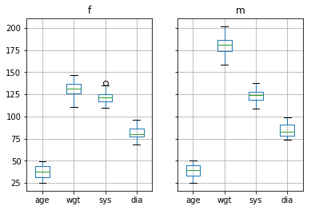

```python
patients.groupby('sex').boxplot(); # Creates a boxplot grouped by sex.
```

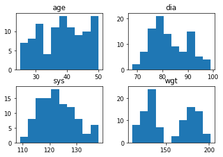

```python
patients.hist(grid=False); # Creates a histogram of the numerical data on the dataframe patients.
```

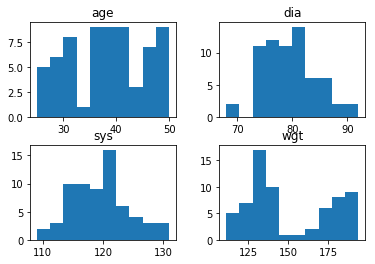

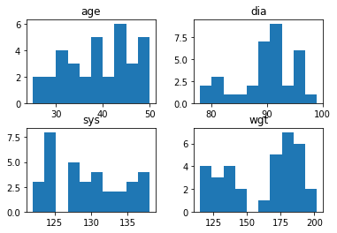

```python
patients.groupby('smoke').hist(grid=False); # Creates a histogram of the numerical data on patients grouped by smoke.
```

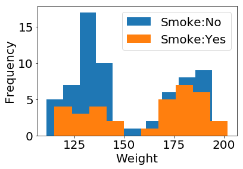

```python
# Displays the histograms of weight grouped by smoke in the same plot.
import matplotlib.pyplot as plt
%matplotlib inline

plt.rcParams.update({'font.size': 20})
plt.figure()
patients.groupby('smoke').wgt.hist()
plt.legend(labels=['Smoke:No','Smoke:Yes'],loc='best')
plt.xlabel('Weight')
plt.ylabel('Frequency')
plt.grid(False)
```

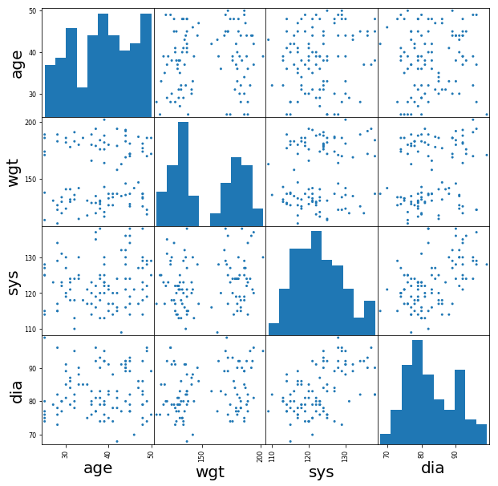

```python
from pandas.plotting import scatter_matrix

scatter_matrix(patients, alpha=1, figsize=(10, 10), diagonal='hist'); # Creates a scatter matrix of the numerical data.
```